# Reproducible Research: Peer Assessment 2

Mark Evans

## Assignment

The basic goal of this assignment is to explore the NOAA Storm Database and answer some basic questions about severe weather events. You must use the database to answer the questions below and show the code for your entire analysis. Your analysis can consist of tables, figures, or other summaries. You may use any R package you want to support your analysis.

## Synopsis

Storms and other severe weather events can cause both public health and economic problems for communities and municipalities. Many severe events can result in fatalities, injuries, and property damage, and preventing such outcomes to the extent possible is a key concern.

This project involves exploring the U.S. National Oceanic and Atmospheric Administration’s (NOAA) storm database. This database tracks characteristics of major storms and weather events in the United States, including when and where they occur, as well as estimates of any fatalities, injuries, and property damage.

The data analysis must address the following questions:

1. Across the United States, which types of events (as indicated in the EVTYPE variable) are most harmful with respect to population health?
2. Across the United States, which types of events have the greatest economic consequences?

## Data Processing

```r
library(plyr)
suppressWarnings(library(ggplot2))

## Download the data.
download.file("https://d396qusza40orc.cloudfront.net/repdata%2Fdata%2FStormData.csv.bz2", "StormData.csv.bz2")
storm <- read.csv(bzfile("StormData.csv.bz2"), sep=",", header=T, stringsAsFactors=FALSE)

## Subset the data only for the columns we care about
storm <- storm[,c('EVTYPE','FATALITIES','INJURIES', 'PROPDMG', 'PROPDMGEXP', 'CROPDMG', 'CROPDMGEXP')]

## Combine the PROPDMG and the PROPDMGEXP columns (as well as the CROPDMG, CROPDMGEXP columns) to total damage columns.
storm$PROPDMGEXP <- mapvalues(storm$PROPDMGEXP,
                         c("K","M","", "B","m","+","0","5","6","?","4","2","3","h","7","H","-","1","8"),
                         c(1e3,1e6, 1, 1e9,1e6,  1,  1,1e5,1e6,  1,1e4,1e2,1e3,1e2,1e7,1e2,  1, 10,1e8))
storm$CROPDMGEXP <- mapvalues(storm$CROPDMGEXP,
                         c("","M","K","m","B","?","0","k","2"),
                         c( 1,1e6,1e3,1e6,1e9,  1,  1, 1e3,1e2))
storm$TOTAL_PROPDMG <- as.numeric(storm$PROPDMGEXP) * storm$PROPDMG
storm$TOTAL_CROPDMG <- as.numeric(storm$CROPDMGEXP) * storm$CROPDMG
```

## Results

### Question 1:

#### Across the US, which types of events are most harmful with respect to population health.

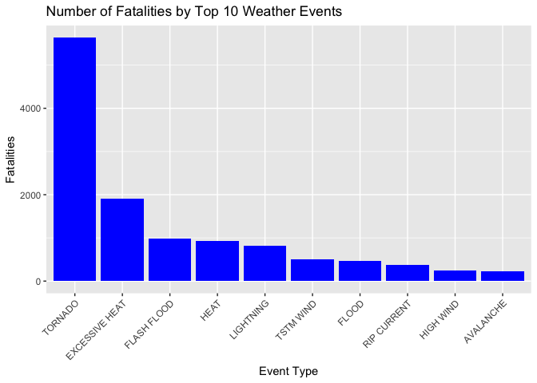

```r
## aggregate the total fatalites based on event type and order greatest to least
fat <- aggregate(FATALITIES ~ EVTYPE, data=storm, sum)
fat <- fat[order(-fat$FATALITIES), ][1:10,]
fat$EVTYPE <- factor(fat$EVTYPE, levels=fat$EVTYPE)

## plot the number of fatalitites by the most harmful event
ggplot(fat, aes(x=EVTYPE, y=FATALITIES)) +
  geom_bar(stat='identity', fill='blue') +
  theme(axis.text.x = element_text(angle = 45, hjust = 1)) +
  labs(x='Event Type', y='Fatalities', title='Number of Fatalities by Top 10 Weather Events')
```

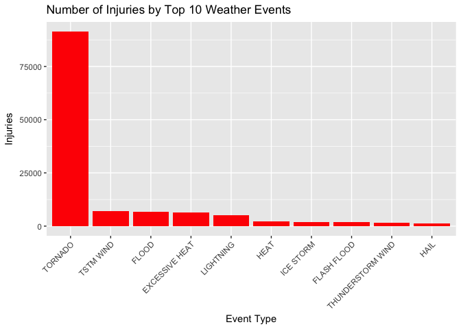

```r
## aggregate the total injuries based on event type and order greatest to least
inj <- aggregate(INJURIES ~ EVTYPE, data=storm, sum)
inj <- inj[order(-inj$INJURIES), ][1:10,]
inj$EVTYPE <- factor(inj$EVTYPE, levels=inj$EVTYPE)

## plot the number of injuries by the most harmful event
ggplot(inj, aes(x=EVTYPE, y=INJURIES)) +
  geom_bar(stat='identity', fill='red') +
  theme(axis.text.x = element_text(angle = 45, hjust = 1)) +
  labs(x='Event Type', y='Injuries', title='Number of Injuries by Top 10 Weather Events')
```

Conclusion: The weather event that causes the most harm to public health is Tornadoes. They have the largest cause of fatalities and injuries due to weather events in the United States.

### Question 2:

#### Across the US, which types of events have the greatest economic consequences?

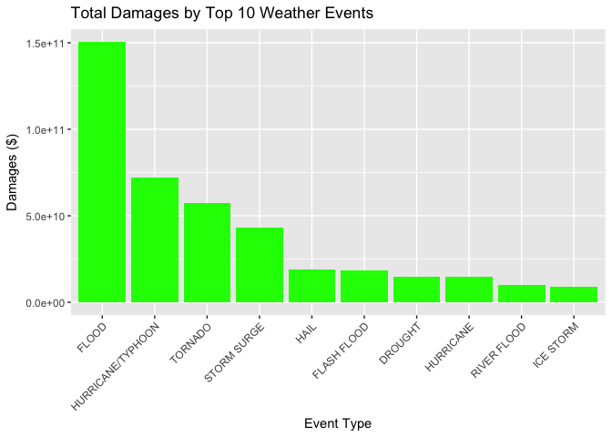

```r
## aggregate the total damages (property and crop) based on event type and order greatest to least
tot <- aggregate(TOTAL_PROPDMG + TOTAL_CROPDMG ~ EVTYPE, data=storm, sum)
names(tot) <- c('EVTYPE', 'TOT_DAM')
tot <- tot[order(-tot$TOT_DAM), ][1:10,]
tot$EVTYPE <- factor(tot$EVTYPE, levels=tot$EVTYPE)

## plot the number of fatalitites by the most harmful event
ggplot(tot, aes(x=EVTYPE, y=TOT_DAM)) +
  geom_bar(stat='identity', fill='green') +
  theme(axis.text.x = element_text(angle = 45, hjust = 1)) +
  labs(x='Event Type', y='Damages ($)', title='Total Damages by Top 10 Weather Events')
```

Conclusion: The event that have caused the most damage in the United states from an economic stand point is Flood.